# lab 05: Predicting MHV Change

## Determining the Reliability of our Indicies

By examining these indicies, we are able to determine the correlation and Cronbach’s Alpha Score (Reliability) for this relationship.

### Selected Variable Correlation:

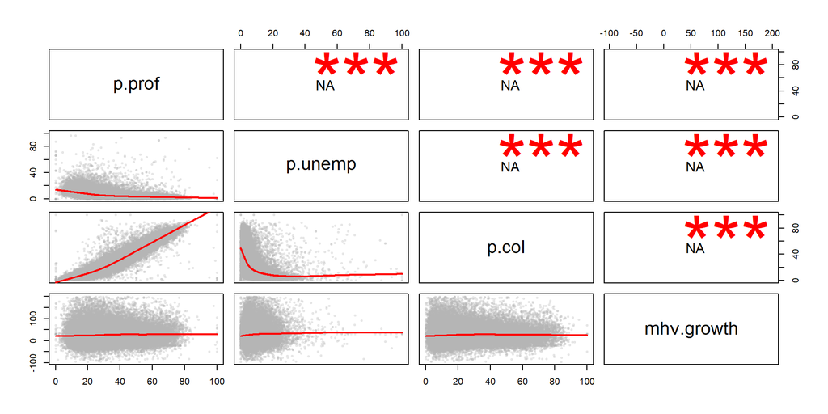

```r
df <- dplyr::select( d, 'p.prof', 'p.unemp', 'p.col', 'mhv.growth' )
pairs( df, lower.panel=panel.smooth, upper.panel=panel.cor )
```

### Selected Variable Alpha Score

```r
a1 <- psych::alpha( df, check.keys=TRUE )$total$raw_alpha
a1
```

```
## [1] 0.3375657
```

### Descriptive Statistics of Metrics.

Below you will find the summary statistics for the variables being analized:

```r
summary (df) %>% pander()
```

| p.prof | p.unemp | p.col | mhv.growth |
| --- | --- | --- | --- |
| Min. : 0.00 | Min. : 0.000 | Min. : 0.00 | Min. :-96.891 |
| 1st Qu.: 22.69 | 1st Qu.: 2.955 | 1st Qu.: 11.88 | 1st Qu.: 5.738 |
| Median : 31.35 | Median : 4.593 | Median : 21.11 | Median : 24.999 |
| Mean : 33.55 | Mean : 6.231 | Mean : 25.67 | Mean : 29.464 |
| 3rd Qu.: 42.87 | 3rd Qu.: 7.573 | 3rd Qu.: 35.89 | 3rd Qu.: 48.733 |
| Max. :100.00 | Max. :100.000 | Max. :100.00 | Max. :199.739 |
| NA’s :192 | NA’s :185 | NA’s :154 | NA’s :766 |

```r
reg.data <- d

reg.data$mhv.growth[ reg.data$mhv.growth > 200 ] <- NA
reg.data$p.prof <- log10( reg.data$p.prof + 1 )
reg.data$p.unemp <- log10( reg.data$p.unemp + 1 )
reg.data$p.col <- log10( reg.data$p.col + 1 )

m1 <- lm( mhv.growth ~  p.prof, data=reg.data )
m2 <- lm( mhv.growth ~  p.unemp, data=reg.data )
m3 <- lm( mhv.growth ~  p.col, data=reg.data )
m4 <- lm( mhv.growth ~  p.prof + p.unemp +p.col, data=reg.data )


stargazer( m1, m2, m3, m4,
           type=s.type, digits=2,
           omit.stat = c("rsq","f") )
```

```
##
## <table style="text-align:center"><tr><td colspan="5" style="border-bottom: 1px solid black"></td></tr><tr><td style="text-align:left"></td><td colspan="4"><em>Dependent variable:</em></td></tr>
## <tr><td></td><td colspan="4" style="border-bottom: 1px solid black"></td></tr>
## <tr><td style="text-align:left"></td><td colspan="4">mhv.growth</td></tr>
## <tr><td style="text-align:left"></td><td>(1)</td><td>(2)</td><td>(3)</td><td>(4)</td></tr>
## <tr><td colspan="5" style="border-bottom: 1px solid black"></td></tr><tr><td style="text-align:left">p.prof</td><td>4.27<sup>***</sup></td><td></td><td></td><td>12.14<sup>***</sup></td></tr>
## <tr><td style="text-align:left"></td><td>(0.74)</td><td></td><td></td><td>(1.82)</td></tr>
## <tr><td style="text-align:left"></td><td></td><td></td><td></td><td></td></tr>
## <tr><td style="text-align:left">p.unemp</td><td></td><td>15.57<sup>***</sup></td><td></td><td>27.11<sup>***</sup></td></tr>
## <tr><td style="text-align:left"></td><td></td><td>(0.56)</td><td></td><td>(0.70)</td></tr>
## <tr><td style="text-align:left"></td><td></td><td></td><td></td><td></td></tr>
## <tr><td style="text-align:left">p.col</td><td></td><td></td><td>2.67<sup>***</sup></td><td>8.53<sup>***</sup></td></tr>
## <tr><td style="text-align:left"></td><td></td><td></td><td>(0.46)</td><td>(1.14)</td></tr>
## <tr><td style="text-align:left"></td><td></td><td></td><td></td><td></td></tr>
## <tr><td style="text-align:left">Constant</td><td>23.04<sup>***</sup></td><td>17.43<sup>***</sup></td><td>25.92<sup>***</sup></td><td>-20.96<sup>***</sup></td></tr>
## <tr><td style="text-align:left"></td><td>(1.11)</td><td>(0.46)</td><td>(0.63)</td><td>(1.88)</td></tr>
## <tr><td style="text-align:left"></td><td></td><td></td><td></td><td></td></tr>
## <tr><td colspan="5" style="border-bottom: 1px solid black"></td></tr><tr><td style="text-align:left">Observations</td><td>58,797</td><td>58,801</td><td>58,822</td><td>58,796</td></tr>
## <tr><td style="text-align:left">Adjusted R<sup>2</sup></td><td>0.001</td><td>0.01</td><td>0.001</td><td>0.03</td></tr>
## <tr><td style="text-align:left">Residual Std. Error</td><td>35.16 (df = 58795)</td><td>34.94 (df = 58799)</td><td>35.17 (df = 58820)</td><td>34.72 (df = 58792)</td></tr>
## <tr><td colspan="5" style="border-bottom: 1px solid black"></td></tr><tr><td style="text-align:left"><em>Note:</em></td><td colspan="4" style="text-align:right"><sup>*</sup>p<0.1; <sup>**</sup>p<0.05; <sup>***</sup>p<0.01</td></tr>
## </table>
```

**Which metric, if any, best predicts change in home value? Does this fit with your expectations?**

**ANSWER:** All three metrics have a significant correlation with change in home value (p<0.01), although the metric that has the most distinct difference would be unemployment.

# Part 3: Predict MHV Change

Now select at least three census variables that you feel will be good predictors of change in MHV between 2000 and 2010.

Run the model while including metro-level fixed effects (cbsa name or FIPS). Make sure you check for variable skew and multicollearity and adjust accordingly.

```r
d.reg <- d

reg.data <- d

d.reg$mhv.growth[ reg.data$mhv.growth > 200 ] <- NA
d.reg$p.prof <- log10( reg.data$p.prof + 1 )
d.reg$p.unemp <- log10( reg.data$p.unemp + 1 )
d.reg$p.col <- log10( reg.data$p.col + 1 )

# average growth in median home value for the city
d.reg <-
  d.reg %>%
  group_by( cbsaname ) %>%
  mutate( metro.mhv.growth = 100 * median( mhv.growth, na.rm=T ) ) %>%
  ungroup()

m1 <- lm( mhv.growth ~ p.prof, data=reg.data )
m2 <- lm( mhv.growth ~ p.unemp, data=reg.data )
m3 <- lm( mhv.growth ~ p.col, data=reg.data )
m4 <- lm( mhv.growth ~ p.prof + p.unemp + p.col + metro.mhv.growth, data=d.reg )
m5 <- lm( mhv.growth ~ p.prof + p.unemp + p.col + cbsa, data=d.reg )

stargazer( m1, m2, m3, m4, m5,
           type=s.type, digits=2,
           omit.stat = c("rsq","f"),
           omit="cbsa",
           add.lines = list(c("Metro Fixed Effects:", "NO", "NO", "No", "No","YES")) )
```

```
##
## <table style="text-align:center"><tr><td colspan="6" style="border-bottom: 1px solid black"></td></tr><tr><td style="text-align:left"></td><td colspan="5"><em>Dependent variable:</em></td></tr>
## <tr><td></td><td colspan="5" style="border-bottom: 1px solid black"></td></tr>
## <tr><td style="text-align:left"></td><td colspan="5">mhv.growth</td></tr>
## <tr><td style="text-align:left"></td><td>(1)</td><td>(2)</td><td>(3)</td><td>(4)</td><td>(5)</td></tr>
## <tr><td colspan="6" style="border-bottom: 1px solid black"></td></tr><tr><td style="text-align:left">p.prof</td><td>0.07<sup>***</sup></td><td></td><td></td><td>-2.86<sup>**</sup></td><td>-3.29<sup>**</sup></td></tr>
## <tr><td style="text-align:left"></td><td>(0.01)</td><td></td><td></td><td>(1.42)</td><td>(1.47)</td></tr>
## <tr><td style="text-align:left"></td><td></td><td></td><td></td><td></td><td></td></tr>
## <tr><td style="text-align:left">p.unemp</td><td></td><td>0.68<sup>***</sup></td><td></td><td>8.92<sup>***</sup></td><td>10.46<sup>***</sup></td></tr>
## <tr><td style="text-align:left"></td><td></td><td>(0.03)</td><td></td><td>(0.55)</td><td>(0.59)</td></tr>
## <tr><td style="text-align:left"></td><td></td><td></td><td></td><td></td><td></td></tr>
## <tr><td style="text-align:left">p.col</td><td></td><td></td><td>0.04<sup>***</sup></td><td>2.19<sup>**</sup></td><td>2.69<sup>***</sup></td></tr>
## <tr><td style="text-align:left"></td><td></td><td></td><td>(0.01)</td><td>(0.89)</td><td>(0.93)</td></tr>
## <tr><td style="text-align:left"></td><td></td><td></td><td></td><td></td><td></td></tr>
## <tr><td style="text-align:left">metro.mhv.growth</td><td></td><td></td><td></td><td>0.01<sup>***</sup></td><td></td></tr>
## <tr><td style="text-align:left"></td><td></td><td></td><td></td><td>(0.0000)</td><td></td></tr>
## <tr><td style="text-align:left"></td><td></td><td></td><td></td><td></td><td></td></tr>
## <tr><td style="text-align:left">Constant</td><td>27.12<sup>***</sup></td><td>25.30<sup>***</sup></td><td>28.34<sup>***</sup></td><td>-1.59</td><td>18.22<sup>***</sup></td></tr>
## <tr><td style="text-align:left"></td><td>(0.37)</td><td>(0.22)</td><td>(0.26)</td><td>(1.47)</td><td>(4.37)</td></tr>
## <tr><td style="text-align:left"></td><td></td><td></td><td></td><td></td><td></td></tr>
## <tr><td colspan="6" style="border-bottom: 1px solid black"></td></tr><tr><td style="text-align:left">Metro Fixed Effects:</td><td>NO</td><td>NO</td><td>No</td><td>No</td><td>YES</td></tr>
## <tr><td style="text-align:left">Observations</td><td>58,797</td><td>58,801</td><td>58,822</td><td>58,796</td><td>58,796</td></tr>
## <tr><td style="text-align:left">Adjusted R<sup>2</sup></td><td>0.001</td><td>0.01</td><td>0.0004</td><td>0.41</td><td>0.41</td></tr>
## <tr><td style="text-align:left">Residual Std. Error</td><td>35.16 (df = 58795)</td><td>34.98 (df = 58799)</td><td>35.17 (df = 58820)</td><td>27.04 (df = 58791)</td><td>26.99 (df = 58414)</td></tr>
## <tr><td colspan="6" style="border-bottom: 1px solid black"></td></tr><tr><td style="text-align:left"><em>Note:</em></td><td colspan="5" style="text-align:right"><sup>*</sup>p<0.1; <sup>**</sup>p<0.05; <sup>***</sup>p<0.01</td></tr>
## </table>
```

**What are the results? Which factor was most important? Did it meet your expectations? Were there any variables that were not significant that you expected to be? Explain your findings to a general audience.**

**Answer:** When running the regression with a cbsa fixed-effects, we notice that the correlation between change in home value and precent professional employees becomes less significant while home values correlgation with precent college graduates actually becomes mroe segnificant. All role of each role is still significant (p<0.05), although the variable that is highly significnt and with a highest rate of change would be unemployement, once again.

Analysis Created By: Ricky Duran For: CPP 528 - Data Sciences for Public Service III Created On: “April 26, 2020”